# Standardregler

## 3. PI-Regler

Erweitern Sie nun den P-Regler zu einem PI-Regler, indem Sie das Proportionalglied um ein Integralglied erweitern. Als weiterer Parameter kommt jetzt die Nachstellzeit $T_N$ hinzu. Verwenden Sie dazu den Positionsalgorithmus. **Achtung:** Der Abstand der Zeitpunkte $\Delta t$ ist bei dieser Simulation nicht konstant! Sie müssen daher den vergangenen Zeitpunkt in einer Variable im Reglerobjekt speichern und die Differenz zum momentanen Zeitpunkt bei jeder Iteration neu berechnen. Speichern Sie auch den vergangenen Wert des Integrals in einer Variable, so dass Sie das Integral $\frac{1}{T_N} \sum_{j=0}^{k-1} e_j \Delta t$ inkrementell bei jedem Zeitschritt berechnen können.

```python
# Hier Ihr PI-Regler als Python-Objekt
'''
Man kann sich den PI-Regler wie einen Tempomaten im Auto vorstellen.
Er merkt sich die Abweichung vom Sollwert über die Zeit, gleicht Verluste wie Luft- und Rollwiderstand aus und kann dadurch eine konstante Geschwindigkeit halten.

Ein reiner P-Regler reagiert hingegen nur auf den momentanen Fehler. Ist das Fahrzeug etwas zu langsam, gibt er Gas; ist es etwas zu schnell, nimmt er Gas weg.
Je nach Reglerverstärkung kann es dabei zu Überschwingen und Schwingungen kommen, und aufgrund der Verluste bleibt oft ein stationärer Fehler bestehen.
'''

class PIController:
    def __init__(self, Kp, Tn, soll=0.0):
        self.Kp = Kp
        self.Tn = Tn
        self.soll = soll

        # interner Zustand
        self.integral = 0.0
        self.t_last = None

    def __call__(self, regelgr, t):
        # Fehler
        e = self.soll - regelgr

        # erstes Aufrufen → kein Δt
        if self.t_last is None:
            dt = 0.0
        else:
            dt = t - self.t_last

        # Integral inkrementell aktualisieren
        if dt > 0.0:
            self.integral += (e * dt) / self.Tn

        # Zeit merken
        self.t_last = t

        # PI-Positionsalgorithmus
        u = self.Kp * (e + self.integral)
        return u
```

**Aufgaben:**

- Testen Sie Ihren PI Regler in der obigen Simulation, zunächst mit $K_p = 1$ und $T_N = 10$. Welcher gravierende Unterschied besteht zum P-Regler?
- Verändern Sie schrittweise die Nachstellzeit. Wie verändert sich das Regelverhalten?
- Was passiert, wenn man zusätzlich die Verstärkung verändert (z.B. Ki = 0.1, 0.01, . . .)?
- Entwerfen Sie mit den bisher gemachten Erfahrungen einen PI-Regler, der ein möglichst gutes Regelverhalten hat, also eine möglichst kurze Einschwingzeit und möglichst geringes Überschwingen.

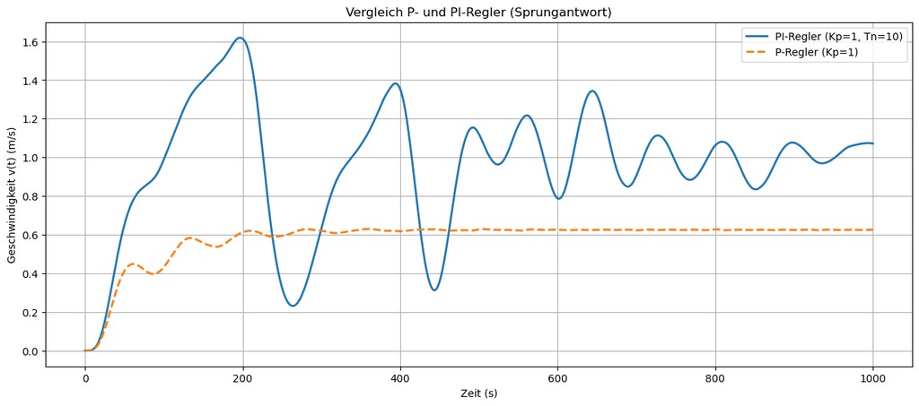

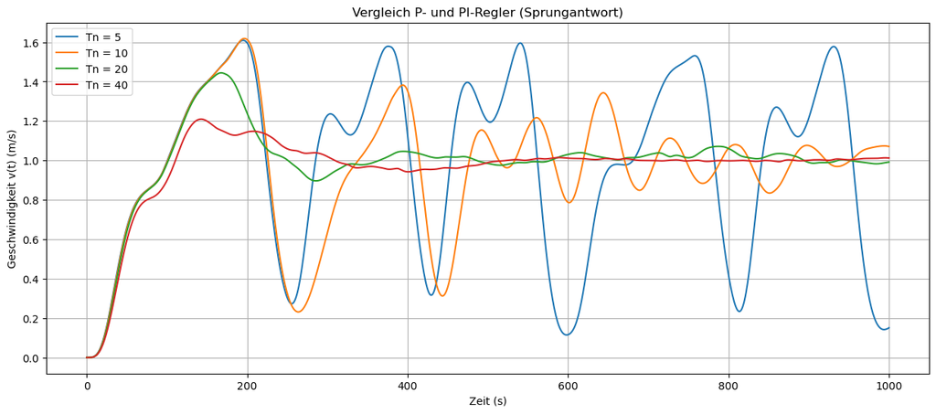

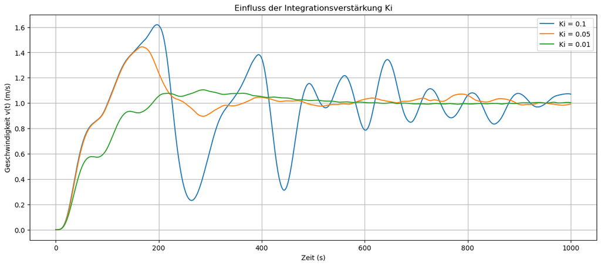

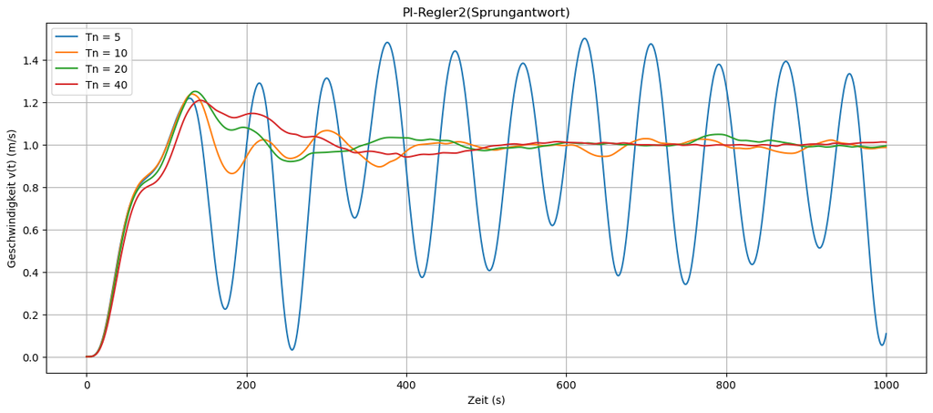

```python
# ==============================
# Aufgabe 1: P vs PI (Kp=1, Tn=10)
# Bei diesem Vergleich erkennt man gut, wie PI-Regler sich dem Soll-wert annähert
# ==============================

Kp = 1.0
Tn = 10.0

plt.figure(figsize=(15,6))

# PI-Regler
ctrl_pi = PIController(Kp=Kp, Tn=Tn, soll=sollwert)
sol_pi = solve_ivp(
    schubverbund_mit_regler2,
    t_span,
    X0,
    args=(ctrl_pi, 1.5),
    t_eval=t_eval
)
plt.plot(sol_pi.t, sol_pi.y[5], label="PI-Regler (Kp=1, Tn=10)", linewidth=2)

# P-Regler
ctrl_p = PController(Kp=Kp, soll=sollwert)
sol_p = solve_ivp(
    schubverbund_mit_regler2,
    t_span,
    X0,
    args=(ctrl_p, 1.5),
    t_eval=t_eval
)
plt.plot(sol_p.t, sol_p.y[5], "--", label="P-Regler (Kp=1)", linewidth=2)

plt.xlabel("Zeit (s)")
plt.ylabel("Geschwindigkeit v(t) (m/s)")
plt.title("Vergleich P- und PI-Regler (Sprungantwort)")
plt.grid(True)
plt.legend()
plt.show()


# ==============================
# Aufgabe 2: Zunehmender Tn anteil
# ==============================
'''
Mit zuenehmender Nachstellzeit Tn wird der Integrationsanteil schwächer,
wodurch sich der Regler langsamer dem Sollwert annähert, das Überschwingen
jedoch reduziert wird. Die stationäre Genauigkeit bleibt unverändert.
'''

plt.figure(figsize=(15,6))

for Tn in [5, 10, 20, 40]:
    ctrl = PIController(Kp=1.0, Tn=Tn, soll=sollwert)
    sol = solve_ivp(
        schubverbund_mit_regler2,
        t_span,
        X0,
        args=(ctrl, 1.5),
        t_eval=t_eval
    )
    plt.plot(sol.t, sol.y[5], label=f"Tn = {Tn}")


plt.xlabel("Zeit (s)")
plt.ylabel("Geschwindigkeit v(t) (m/s)")
plt.title("Vergleich P- und PI-Regler (Sprungantwort)")
plt.grid(True)
plt.legend()
plt.show()



# ==============================
# Aufgabe 3: Einfluss von Ki
# ==============================
'''
Eine große Integrationsverstärkung Ki beschleunigt den Fehlerabbau,
erhöht jedoch das Überschwingen. Eine kleinere Wahl von Ki
führt zu einem stabileren, aber langsameren Regelverhalten.
'''
plt.figure(figsize=(15,6))

for Ki in [0.1, 0.05, 0.01]:
    Tn = 1.0 / Ki
    ctrl = PIController(Kp=1.0, Tn=Tn, soll=sollwert)
    sol = solve_ivp(
        schubverbund_mit_regler2,
        t_span,
        X0,
        args=(ctrl, 1.5),
        t_eval=t_eval
    )
    plt.plot(sol.t, sol.y[5], label=f"Ki = {Ki}")

plt.xlabel("Zeit (s)")
plt.ylabel("Geschwindigkeit v(t) (m/s)")
plt.title("Einfluss der Integrationsverstärkung Ki")
plt.grid(True)
plt.legend()
plt.show()


# ==============================
# Aufgabe 4: Redesigned cleaner PI-Regler
# ==============================

class PIController2:
    def __init__(self, Kp, Tn, soll=0.0, u_min=-1.5, u_max=1.5):
        self.Kp = Kp
        self.Tn = Tn
        self.soll = soll

        # Stellgrößenbeschränkung
        self.u_min = u_min
        self.u_max = u_max

        # interner Zustand
        self.integral = 0.0
        self.t_last = None

    def reset(self):
        self.integral = 0.0
        self.t_last = None

    def __call__(self, regelgr, t):
        # Regelfehler
        e = self.soll - regelgr

        # Zeitschritt
        if self.t_last is None:
            dt = 0.0
        else:
            dt = t - self.t_last
        self.t_last = t

        # PI-Berechnung (ungebegrenzte Stellgröße)
        if dt > 0.0:
            self.integral += (e * dt) / self.Tn

        u_unclamped = self.Kp * (e + self.integral)

        # Stellgrößenbegrenzung
        u = max(self.u_min, min(self.u_max, u_unclamped))

        # Anti-Windup: Integration nur wenn keine Sättigung vorliegt
        if u != u_unclamped and dt > 0.0:
            self.integral -= (e * dt) / self.Tn

        return u

plt.figure(figsize=(15,6))

for Tn in [5, 10, 20, 40]:
    ctrl = PIController2(Kp=1.0, Tn=Tn, soll=sollwert)
    sol = solve_ivp(
        schubverbund_mit_regler2,
        t_span,
        X0,
        args=(ctrl, 1.5),
        t_eval=t_eval
    )
    plt.plot(sol.t, sol.y[5], label=f"Tn = {Tn}")


plt.xlabel("Zeit (s)")
plt.ylabel("Geschwindigkeit v(t) (m/s)")
plt.title("PI-Regler2(Sprungantwort)")
plt.grid(True)
plt.legend()
plt.show()
```